# Review of Linear Regression (ELMR Chapter 1)

Biostat 200C

Dr. Jin Zhou @ UCLA

Apr 6, 2023

Display system information and load `tidyverse` and `faraway` packages

```r
library(tidyverse)
library(faraway)
```

`faraway` package contains the datasets in the ELMR book.

## GA 2000 US Presidential Election Data

The `gavote` data contains the voting data of Georgia (GA) in the 2000 presidential election. It is available as a dataframe.

```r
# equivalent to head(gavote, 10)
gavote %>% head(10)
```

```
##          equip   econ perAA rural    atlanta gore  bush other votes ballots
## APPLING  LEVER   poor 0.182 rural notAtlanta 2093  3940    66  6099    6617
## ATKINSON LEVER   poor 0.230 rural notAtlanta  821  1228    22  2071    2149
## BACON    LEVER   poor 0.131 rural notAtlanta  956  2010    29  2995    3347
## BAKER    OS-CC   poor 0.476 rural notAtlanta  893   615    11  1519    1607
## BALDWIN  LEVER middle 0.359 rural notAtlanta 5893  6041   192 12126   12785
## BANKS    LEVER middle 0.024 rural notAtlanta 1220  3202   111  4533    4773
## BARROW   OS-CC middle 0.079 urban notAtlanta 3657  7925   520 12102   12522
## BARTOW   OS-PC middle 0.079 urban    Atlanta 7508 14720   552 22780   23735
## BEN.HILL OS-PC   poor 0.282 rural notAtlanta 2234  2381    46  4661    5741
## BERRIEN  OS-CC   poor 0.107 rural notAtlanta 1640  2718    52  4410    4475
```

We convert it into a tibble for easy handling by tidyverse.

```r
gavote <- gavote %>%
  as_tibble(rownames = "county") %>%
  print(width = Inf)
```

```
## # A tibble: 159 × 11
##    county   equip econ   perAA rural atlanta     gore  bush other votes ballots
##    <chr>    <fct> <fct>  <dbl> <fct> <fct>      <int> <int> <int> <int>   <int>
##  1 APPLING  LEVER poor   0.182 rural notAtlanta  2093  3940    66  6099    6617
##  2 ATKINSON LEVER poor   0.23  rural notAtlanta   821  1228    22  2071    2149
##  3 BACON    LEVER poor   0.131 rural notAtlanta   956  2010    29  2995    3347
##  4 BAKER    OS-CC poor   0.476 rural notAtlanta   893   615    11  1519    1607
##  5 BALDWIN  LEVER middle 0.359 rural notAtlanta  5893  6041   192 12126   12785
##  6 BANKS    LEVER middle 0.024 rural notAtlanta  1220  3202   111  4533    4773
##  7 BARROW   OS-CC middle 0.079 urban notAtlanta  3657  7925   520 12102   12522
##  8 BARTOW   OS-PC middle 0.079 urban Atlanta     7508 14720   552 22780   23735
##  9 BEN.HILL OS-PC poor   0.282 rural notAtlanta  2234  2381    46  4661    5741
## 10 BERRIEN  OS-CC poor   0.107 rural notAtlanta  1640  2718    52  4410    4475
## # … with 149 more rows
```

`str` function is useful for inspecting contents of any R object.

```r
str(gavote)
```

```
## tibble [159 × 11] (S3: tbl_df/tbl/data.frame)
##  $ county : chr [1:159] "APPLING" "ATKINSON" "BACON" "BAKER" ...
##  $ equip  : Factor w/ 5 levels "LEVER","OS-CC",..: 1 1 1 2 1 1 2 3 3 2 ...
##  $ econ   : Factor w/ 3 levels "middle","poor",..: 2 2 2 2 1 1 1 1 2 2 ...
##  $ perAA  : num [1:159] 0.182 0.23 0.131 0.476 0.359 0.024 0.079 0.079 0.282 0.107 ...
##  $ rural  : Factor w/ 2 levels "rural","urban": 1 1 1 1 1 1 2 2 1 1 ...
##  $ atlanta: Factor w/ 2 levels "Atlanta","notAtlanta": 2 2 2 2 2 2 2 1 2 2 ...
##  $ gore   : int [1:159] 2093 821 956 893 5893 1220 3657 7508 2234 1640 ...
##  $ bush   : int [1:159] 3940 1228 2010 615 6041 3202 7925 14720 2381 2718 ...
##  $ other  : int [1:159] 66 22 29 11 192 111 520 552 46 52 ...
##  $ votes  : int [1:159] 6099 2071 2995 1519 12126 4533 12102 22780 4661 4410 ...
##  $ ballots: int [1:159] 6617 2149 3347 1607 12785 4773 12522 23735 5741 4475 ...
```

- Each row is a county in GA.
- The number of votes, `votes`, can be smaller than the number of ballots, `ballots`, because a vote is not recorded if (1) the person fails to vote for President, (2) votes for more than one candidate, or (3) the equipment fails to record the vote.
- We are interested in the `undercount`, which is defined as `(ballots - votes) / ballots`. Does it depend on the type of voting machine `equip`, economy `econ`, percentage of African Americans `perAA`, whether the county is rural or urban `rural`, or whether the county is part of Atlanta metropolitan area `atlanta`.

  Let’s create a new variable `undercount`

```r
gavote <- gavote %>%
  mutate(undercount = (ballots - votes) / ballots) %>%
  print(width = Inf)
```

```
## # A tibble: 159 × 12
##    county   equip econ   perAA rural atlanta     gore  bush other votes ballots
##    <chr>    <fct> <fct>  <dbl> <fct> <fct>      <int> <int> <int> <int>   <int>
##  1 APPLING  LEVER poor   0.182 rural notAtlanta  2093  3940    66  6099    6617
##  2 ATKINSON LEVER poor   0.23  rural notAtlanta   821  1228    22  2071    2149
##  3 BACON    LEVER poor   0.131 rural notAtlanta   956  2010    29  2995    3347
##  4 BAKER    OS-CC poor   0.476 rural notAtlanta   893   615    11  1519    1607
##  5 BALDWIN  LEVER middle 0.359 rural notAtlanta  5893  6041   192 12126   12785
##  6 BANKS    LEVER middle 0.024 rural notAtlanta  1220  3202   111  4533    4773
##  7 BARROW   OS-CC middle 0.079 urban notAtlanta  3657  7925   520 12102   12522
##  8 BARTOW   OS-PC middle 0.079 urban Atlanta     7508 14720   552 22780   23735
##  9 BEN.HILL OS-PC poor   0.282 rural notAtlanta  2234  2381    46  4661    5741
## 10 BERRIEN  OS-CC poor   0.107 rural notAtlanta  1640  2718    52  4410    4475
##    undercount
##         <dbl>
##  1     0.0783
##  2     0.0363
##  3     0.105
##  4     0.0548
##  5     0.0515
##  6     0.0503
##  7     0.0335
##  8     0.0402
##  9     0.188
## 10     0.0145
## # … with 149 more rows
```

## Descriptive statistics

Numerical summaries:

```r
summary(gavote)
```

```
##     county            equip        econ        perAA          rural
##  Length:159         LEVER:74   middle:69   Min.   :0.0000   rural:117
##  Class :character   OS-CC:44   poor  :72   1st Qu.:0.1115   urban: 42
##  Mode  :character   OS-PC:22   rich  :18   Median :0.2330
##                     PAPER: 2               Mean   :0.2430
##                     PUNCH:17               3rd Qu.:0.3480
##                                            Max.   :0.7650
##        atlanta         gore             bush            other
##  Atlanta   : 15   Min.   :   249   Min.   :   271   Min.   :   5.0
##  notAtlanta:144   1st Qu.:  1386   1st Qu.:  1804   1st Qu.:  30.0
##                   Median :  2326   Median :  3597   Median :  86.0
##                   Mean   :  7020   Mean   :  8929   Mean   : 381.7
##                   3rd Qu.:  4430   3rd Qu.:  7468   3rd Qu.: 210.0
##                   Max.   :154509   Max.   :140494   Max.   :7920.0
##      votes           ballots         undercount
##  Min.   :   832   Min.   :   881   Min.   :0.00000
##  1st Qu.:  3506   1st Qu.:  3694   1st Qu.:0.02779
##  Median :  6299   Median :  6712   Median :0.03983
##  Mean   : 16331   Mean   : 16926   Mean   :0.04379
##  3rd Qu.: 11846   3rd Qu.: 12251   3rd Qu.:0.05647
##  Max.   :263211   Max.   :280975   Max.   :0.18812
```

- For factor `rural`, we found the variable name is same as one level in this factor. To avoid confusion, we rename it to `usage`.

  We also want to standardize the counts `gore` and `bush` according to the total `votes`.

```r
(gavote <- gavote %>%
  rename(usage = rural) %>%
  mutate(pergore = gore / votes, perbush = bush / votes)) %>%
  print(width = Inf)
```

```
## # A tibble: 159 × 14
##    county   equip econ   perAA usage atlanta     gore  bush other votes ballots
##    <chr>    <fct> <fct>  <dbl> <fct> <fct>      <int> <int> <int> <int>   <int>
##  1 APPLING  LEVER poor   0.182 rural notAtlanta  2093  3940    66  6099    6617
##  2 ATKINSON LEVER poor   0.23  rural notAtlanta   821  1228    22  2071    2149
##  3 BACON    LEVER poor   0.131 rural notAtlanta   956  2010    29  2995    3347
##  4 BAKER    OS-CC poor   0.476 rural notAtlanta   893   615    11  1519    1607
##  5 BALDWIN  LEVER middle 0.359 rural notAtlanta  5893  6041   192 12126   12785
##  6 BANKS    LEVER middle 0.024 rural notAtlanta  1220  3202   111  4533    4773
##  7 BARROW   OS-CC middle 0.079 urban notAtlanta  3657  7925   520 12102   12522
##  8 BARTOW   OS-PC middle 0.079 urban Atlanta     7508 14720   552 22780   23735
##  9 BEN.HILL OS-PC poor   0.282 rural notAtlanta  2234  2381    46  4661    5741
## 10 BERRIEN  OS-CC poor   0.107 rural notAtlanta  1640  2718    52  4410    4475
##    undercount pergore perbush
##         <dbl>   <dbl>   <dbl>
##  1     0.0783   0.343   0.646
##  2     0.0363   0.396   0.593
##  3     0.105    0.319   0.671
##  4     0.0548   0.588   0.405
##  5     0.0515   0.486   0.498
##  6     0.0503   0.269   0.706
##  7     0.0335   0.302   0.655
##  8     0.0402   0.330   0.646
##  9     0.188    0.479   0.511
## 10     0.0145   0.372   0.616
## # … with 149 more rows
```

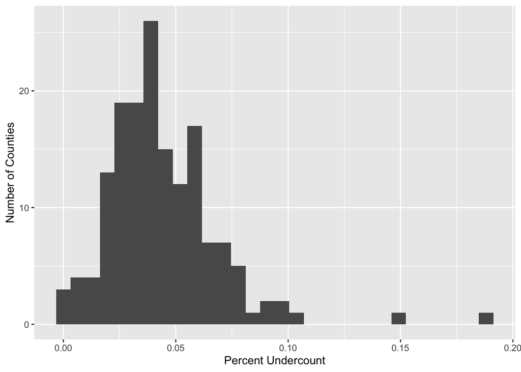

```r
ggplot(data = gavote) +
  geom_histogram(mapping = aes(x = undercount)) +
  labs(x = "Percent Undercount", y = "Number of Counties")
```

- A scatter plot reveals relationship between two continuous variables.

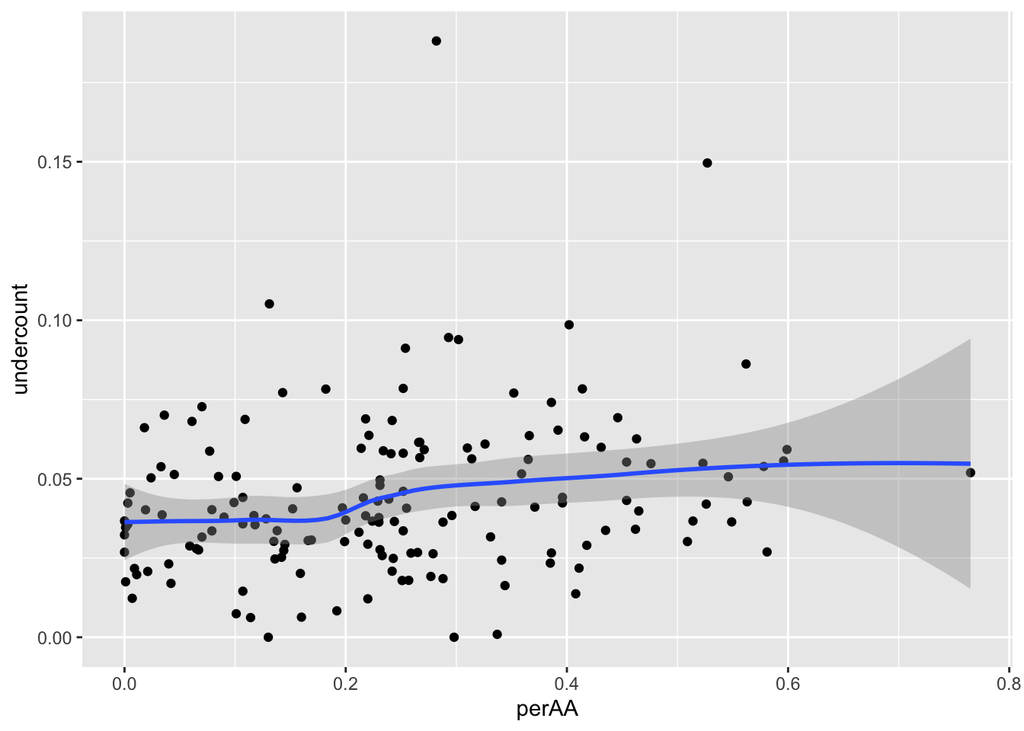

```r
ggplot(data = gavote, mapping = aes(x = perAA, y = undercount)) +
  geom_point() +
  geom_smooth()
```

- Let’s further stratify according to factors `equip`, `econ`, `usage`, and `atlanta`.

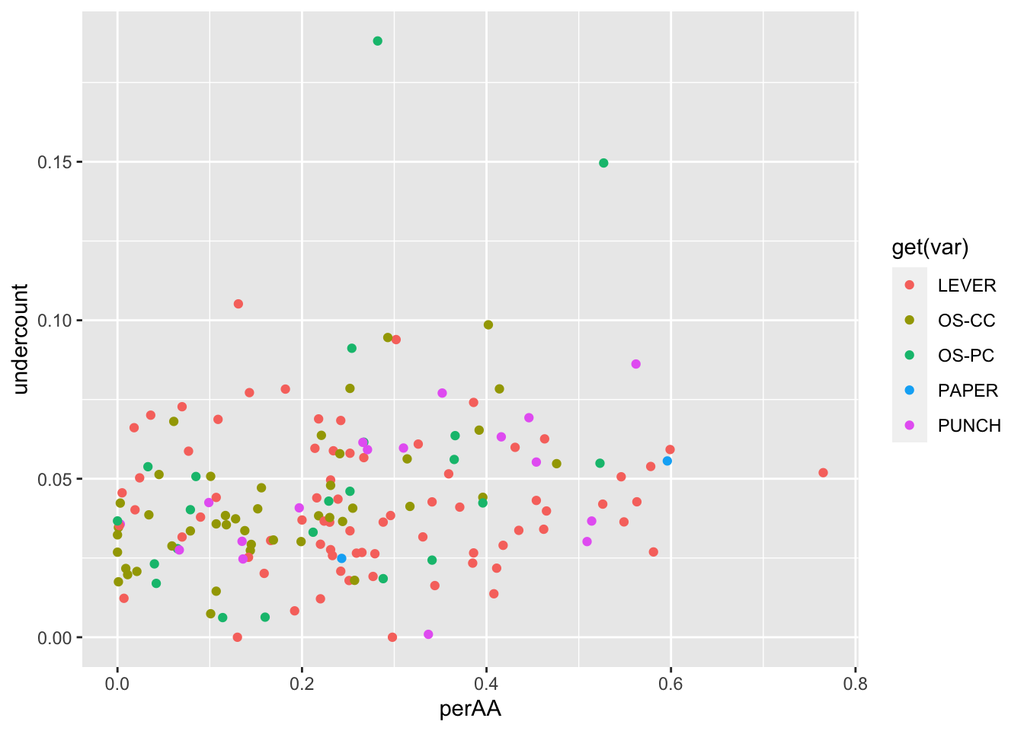

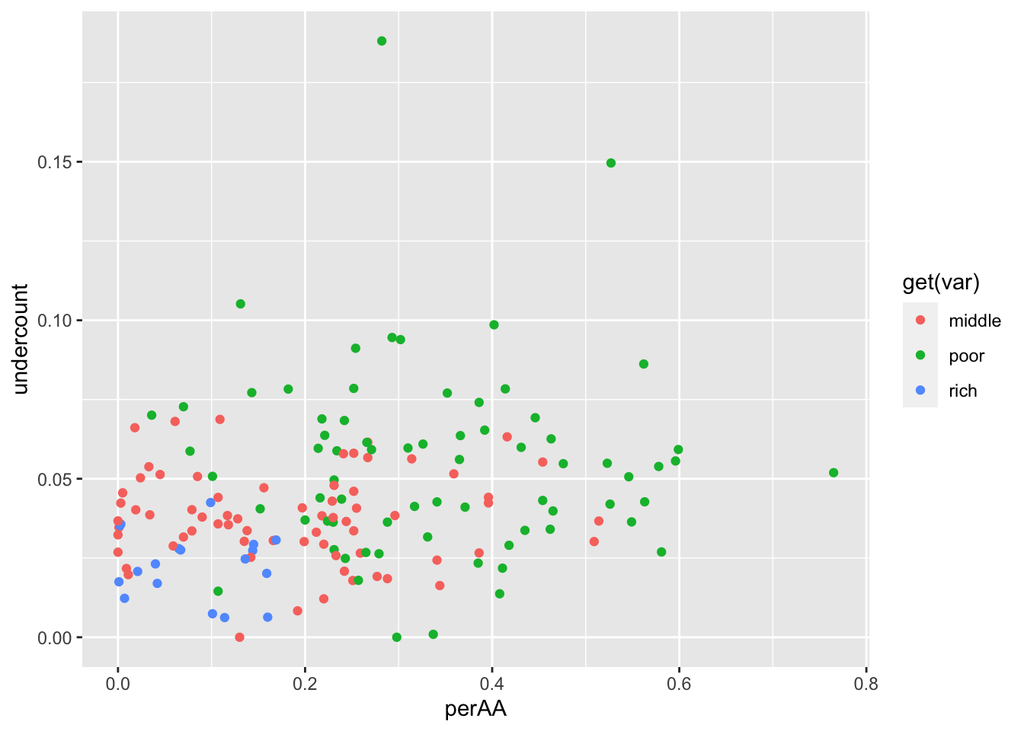

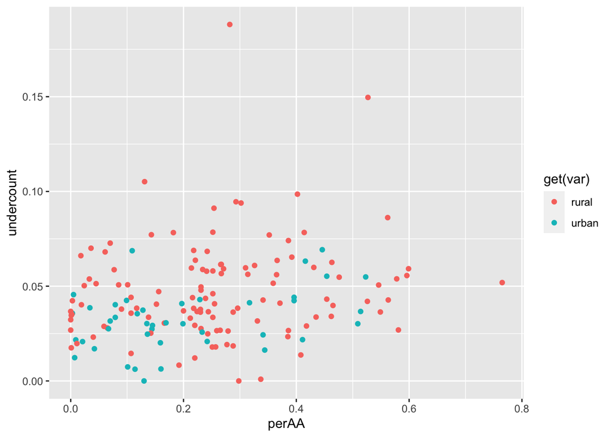

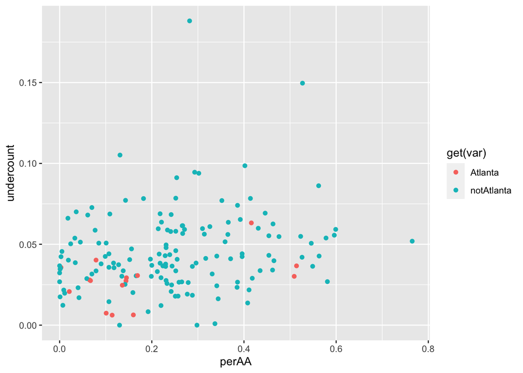

```r
for (var in c("equip", "econ", "usage", "atlanta")) {
  plot <- ggplot(data = gavote) +
    geom_point(mapping = aes(x = perAA, y = undercount, color = get(var)))
  print(plot)
}
```

- For qualitative predictors, we can also do side-by-side box plots to reveal potential relationship with responses.
  - What does boxplot show us?
  - Any other plots do you usually use beside boxplot?
    - Violin plot

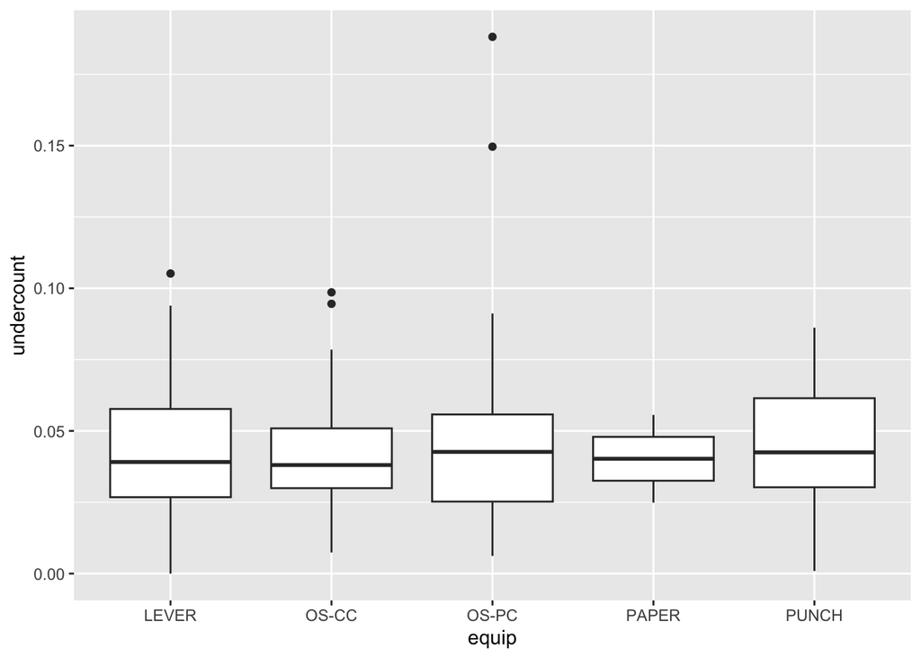

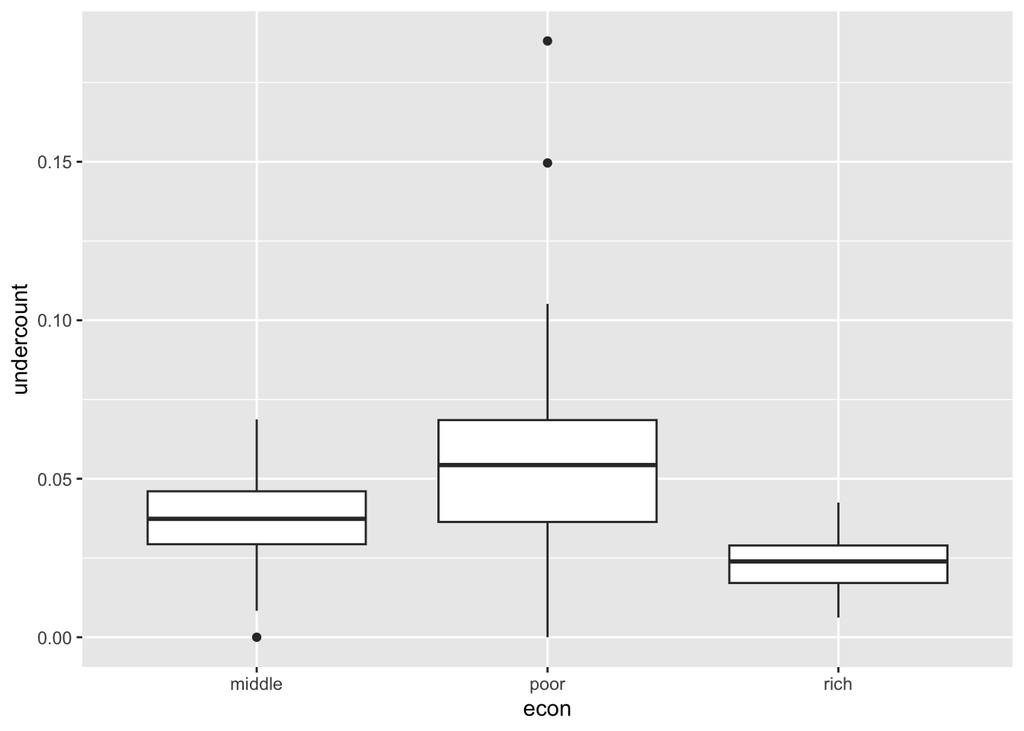

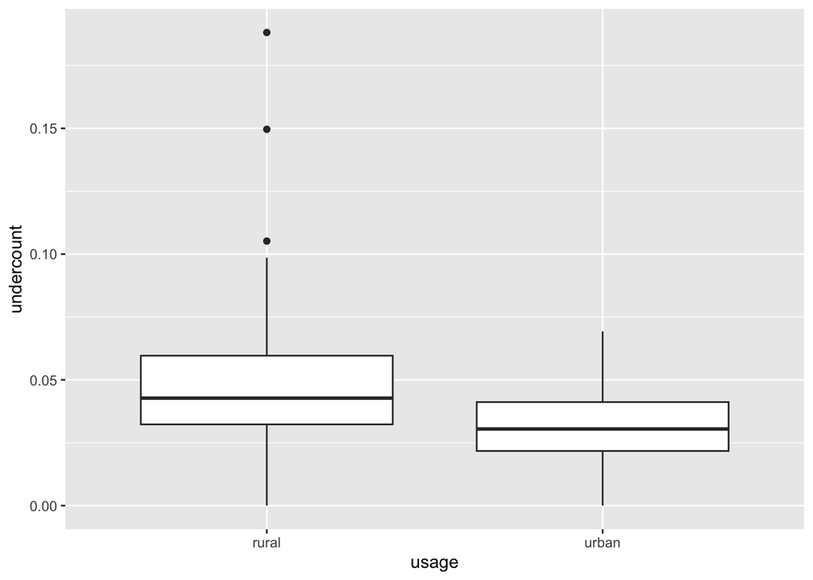

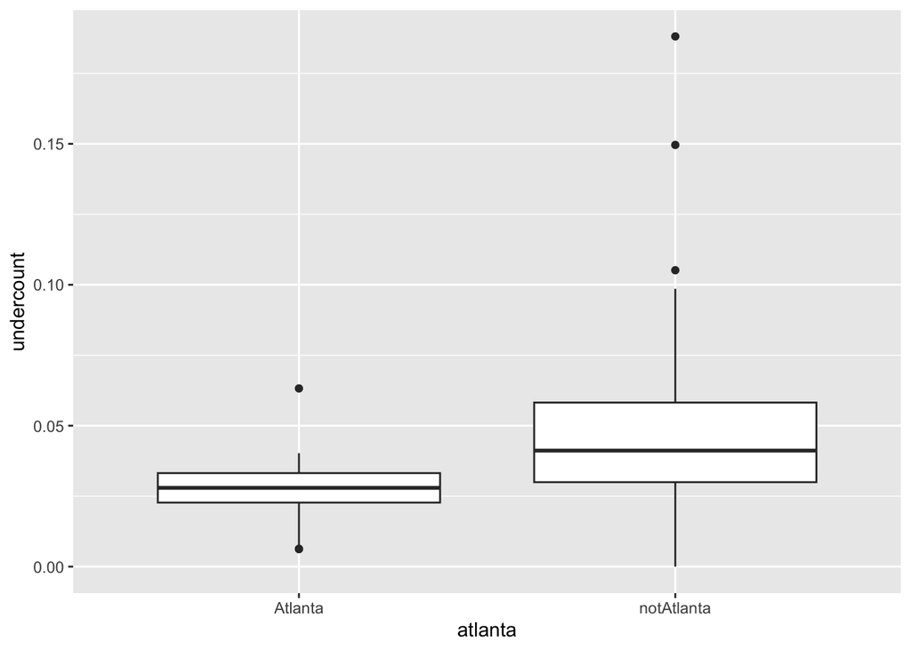

```r
for (var in c("equip", "econ", "usage", "atlanta")) {
  plot <- ggplot(data = gavote) +
    geom_boxplot(mapping = aes(x = get(var), y = undercount)) +
    xlab(var)
  print(plot)
}
```

- Pairwise scatter plots are useful to explore the relationships between several continuous variables. We use the `ggpairs` function from [`GGally`](https://ggobi.github.io/ggally/) package ([`GGally` examples](http://www.sthda.com/english/wiki/ggally-r-package-extension-to-ggplot2-for-correlation-matrix-and-survival-plots-r-software-and-data-visualization)).

```r
library(GGally)
```

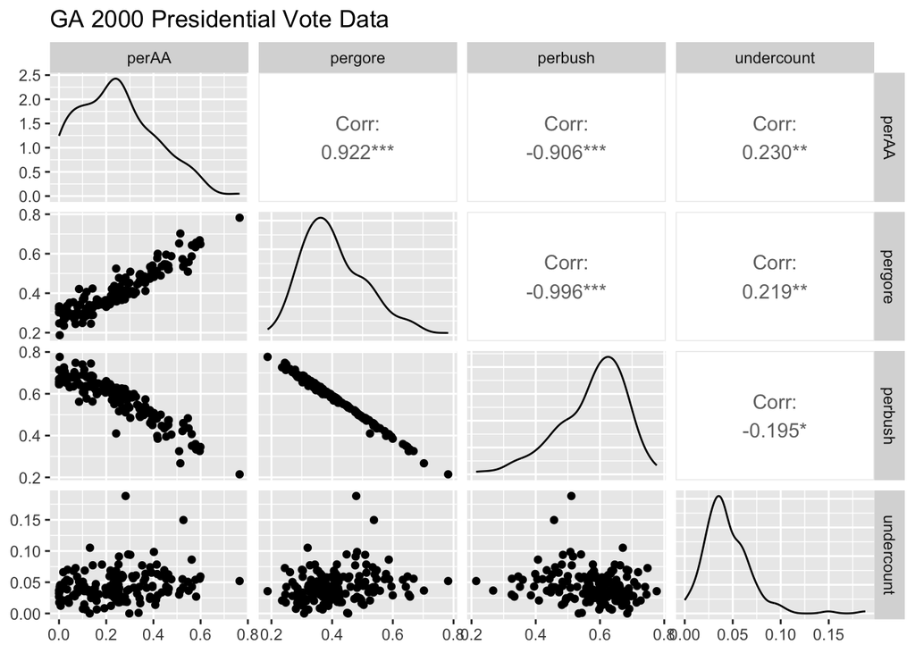

```r
ggpairs(data = gavote, columns = c(4, 13, 14, 12)) +
  labs(title = "GA 2000 Presidential Vote Data")
```

## Linear model

- To formally study how `undercount` is affected by other variables, we postulate a linear model
  $$Y = \beta_0 + \beta_1 X_1 + \beta_2 X_2 + \cdots + \beta_{p-1} X_{p-1} +
  \epsilon,$$
  where
  - the **response variable** or **dependent variable** $Y$ is the `undercount`, the variable of interest,
  - the **predictors** $X_1,\ldots,X_{p-1}$ encodes the predictors `perAA`, `econ`, etc.,
  - the **regression coefficients** or **parameters** $\beta_0, \ldots, \beta_{p-1}$ reflects the effects of predictors on response variable $Y$, especially $\beta_0$ is called the **intercept**, and
  - the **error term** $\epsilon$ includes measurement error.
- In matrix-vector notations, we have
  $$\mathbf{y} = \mathbf{X} \boldsymbol{\beta} + \boldsymbol{\epsilon},$$
  where, in terms of $n$ data points,
  $$\mathbf{y} = \begin{pmatrix} y_1 \\ \vdots \\ y_n \end{pmatrix}, \quad
  \mathbf{X} = \begin{pmatrix}
  1 & x_{11} & x_{12} & \cdots & x_{1,p-1} \\
  1 & x_{21} & x_{22} & \cdots & x_{2,p-1} \\
  \vdots & & \vdots & & \vdots \\
  1 & x_{n1} & x_{n2} & \cdots & x_{n,p-1}
  \end{pmatrix}, \quad
  \boldsymbol{\beta} = \begin{pmatrix} \beta_0 \\ \vdots \\ \beta_{p-1}
  \end{pmatrix}, \quad \boldsymbol{\epsilon} = \begin{pmatrix} \epsilon_1
  \\ \vdots \\ \epsilon_n \end{pmatrix}.$$
- The **least squares estimate** of $\boldsymbol{\beta}$, called $\widehat{\boldsymbol{\beta}}$, minimizes
  $$\|\boldsymbol{\epsilon}\|^2 = \sum_i \epsilon_i^2 =
  \boldsymbol{\epsilon}^T \boldsymbol{\epsilon} = (\mathbf{y} - \mathbf{X}
  \boldsymbol{\beta})^T (\mathbf{y} - \mathbf{X} \boldsymbol{\beta}) =
  \|\mathbf{y} - \mathbf{X} \boldsymbol{\beta}\|^2.$$
- It’s important to keep in mind that the least squares estimate only assumes that
  1. $\mathbb{E}(\mathbf{Y}) = \mathbf{X} \boldsymbol{\beta}$ (errors have mean 0), and
  2. $\text{Var}(\mathbf{Y}) = \sigma_0^2 \mathbf{I}_n$ (errors are independent with common variance).  
     Under these assumptions, the celebrated Gauss-Markov theorem states that the least squares estimate is the best (smallest variance) linear unbiased estimates.

  It is the inference part (p-value, standard errors, confidence intervals) that uses the normality assumption
  3. $\mathbf{Y} \sim \text{N}(\mathbf{X} \boldsymbol{\beta}, \sigma_0^2 \mathbf{I}_n)$.
- Under normality assumption, the least squares estimate coincides with the maximum likelihood estimate (MLE).

## A model with two quantitative predictors

- We start with a linear model with just two predictors: percentage of Gore votes, `pergore`, and percentage of African Americans, `perAA`.
  $$\text{undercount} = \beta_0 + \beta_1 \cdot \text{pergore} + \beta_2
  \cdot \text{perAA} + \epsilon.$$

### `lm`

```r
(lmod <- lm(undercount ~ pergore + perAA, gavote))
```

```
##
## Call:
## lm(formula = undercount ~ pergore + perAA, data = gavote)
##
## Coefficients:
## (Intercept)      pergore        perAA
##     0.03238      0.01098      0.02853
```

Inspection of the result, stored in `lmod`, shows that it contains rich regression information.

```r
str(lmod)
```

```
## List of 12
##  $ coefficients : Named num [1:3] 0.0324 0.011 0.0285
##   ..- attr(*, "names")= chr [1:3] "(Intercept)" "pergore" "perAA"
##  $ residuals    : Named num [1:159] 0.03695 -0.00699 0.06555 0.00235 0.00359 ...
##   ..- attr(*, "names")= chr [1:159] "1" "2" "3" "4" ...
##  $ effects      : Named num [1:159] -5.52e-01 6.87e-02 -2.27e-02 1.20e-05 -7.94e-05 ...
##   ..- attr(*, "names")= chr [1:159] "(Intercept)" "pergore" "perAA" "" ...
##  $ rank         : int 3
##  $ fitted.values: Named num [1:159] 0.0413 0.0433 0.0396 0.0524 0.048 ...
##   ..- attr(*, "names")= chr [1:159] "1" "2" "3" "4" ...
##  $ assign       : int [1:3] 0 1 2
##  $ qr           :List of 5
##   ..$ qr   : num [1:159, 1:3] -12.6095 0.0793 0.0793 0.0793 0.0793 ...
##   .. ..- attr(*, "dimnames")=List of 2
##   .. .. ..$ : chr [1:159] "1" "2" "3" "4" ...
##   .. .. ..$ : chr [1:3] "(Intercept)" "pergore" "perAA"
##   .. ..- attr(*, "assign")= int [1:3] 0 1 2
##   ..$ qraux: num [1:3] 1.08 1.01 1.01
##   ..$ pivot: int [1:3] 1 2 3
##   ..$ tol  : num 1e-07
##   ..$ rank : int 3
##   ..- attr(*, "class")= chr "qr"
##  $ df.residual  : int 156
##  $ xlevels      : Named list()
##  $ call         : language lm(formula = undercount ~ pergore + perAA, data = gavote)
##  $ terms        :Classes 'terms', 'formula'  language undercount ~ pergore + perAA
##   .. ..- attr(*, "variables")= language list(undercount, pergore, perAA)
##   .. ..- attr(*, "factors")= int [1:3, 1:2] 0 1 0 0 0 1
##   .. .. ..- attr(*, "dimnames")=List of 2
##   .. .. .. ..$ : chr [1:3] "undercount" "pergore" "perAA"
##   .. .. .. ..$ : chr [1:2] "pergore" "perAA"
##   .. ..- attr(*, "term.labels")= chr [1:2] "pergore" "perAA"
##   .. ..- attr(*, "order")= int [1:2] 1 1
##   .. ..- attr(*, "intercept")= int 1
##   .. ..- attr(*, "response")= int 1
##   .. ..- attr(*, ".Environment")=<environment: R_GlobalEnv>
##   .. ..- attr(*, "predvars")= language list(undercount, pergore, perAA)
##   .. ..- attr(*, "dataClasses")= Named chr [1:3] "numeric" "numeric" "numeric"
##   .. .. ..- attr(*, "names")= chr [1:3] "undercount" "pergore" "perAA"
##  $ model        :'data.frame':   159 obs. of  3 variables:
##   ..$ undercount: num [1:159] 0.0783 0.0363 0.1052 0.0548 0.0515 ...
##   ..$ pergore   : num [1:159] 0.343 0.396 0.319 0.588 0.486 ...
##   ..$ perAA     : num [1:159] 0.182 0.23 0.131 0.476 0.359 0.024 0.079 0.079 0.282 0.107 ...
##   ..- attr(*, "terms")=Classes 'terms', 'formula'  language undercount ~ pergore + perAA
##   .. .. ..- attr(*, "variables")= language list(undercount, pergore, perAA)
##   .. .. ..- attr(*, "factors")= int [1:3, 1:2] 0 1 0 0 0 1
##   .. .. .. ..- attr(*, "dimnames")=List of 2
##   .. .. .. .. ..$ : chr [1:3] "undercount" "pergore" "perAA"
##   .. .. .. .. ..$ : chr [1:2] "pergore" "perAA"
##   .. .. ..- attr(*, "term.labels")= chr [1:2] "pergore" "perAA"
##   .. .. ..- attr(*, "order")= int [1:2] 1 1
##   .. .. ..- attr(*, "intercept")= int 1
##   .. .. ..- attr(*, "response")= int 1
##   .. .. ..- attr(*, ".Environment")=<environment: R_GlobalEnv>
##   .. .. ..- attr(*, "predvars")= language list(undercount, pergore, perAA)
##   .. .. ..- attr(*, "dataClasses")= Named chr [1:3] "numeric" "numeric" "numeric"
##   .. .. .. ..- attr(*, "names")= chr [1:3] "undercount" "pergore" "perAA"
##  - attr(*, "class")= chr "lm"
```

- The **regression coefficient** $\widehat{\boldsymbol{\beta}}$ can be retrieved by

```r
# same lmod$coefficients
coef(lmod)
```

```
## (Intercept)     pergore       perAA
##  0.03237600  0.01097872  0.02853314
```

- The **fitted values** or **predicted values** are
  $$\widehat{\mathbf{y}} = \mathbf{X} \widehat{\boldsymbol{\beta}}$$

```r
# same as lmod$fitted.values
predict(lmod) %>% head()
```

```
##          1          2          3          4          5          6
## 0.04133661 0.04329088 0.03961823 0.05241202 0.04795484 0.03601558
```

and the **residuals** are
$$\widehat{\boldsymbol{\epsilon}} = \mathbf{y} - \widehat{\mathbf{y}} =
\mathbf{y} - \mathbf{X} \widehat{\boldsymbol{\beta}}.$$

```r
# same as lmod$residuals
residuals(lmod) %>% head()
```

```
##            1            2            3            4            5            6
##  0.036946603 -0.006994927  0.065550577  0.002348407  0.003589940  0.014267264
```

- The **residual sum of squares** (RSS), also called **deviance**, is $\|\widehat{\boldsymbol{\epsilon}}\|^2$.

```r
deviance(lmod)
```

```
## [1] 0.09324918
```

- The **degree of freedom** of a linear model is $n-p$.

```r
nrow(gavote) - length(coef(lmod))
```

```
## [1] 156
```

```r
df.residual(lmod)
```

```
## [1] 156
```

### `summary`

- The `summary` command computes some more regression quantities.

```r
(lmodsum <- summary(lmod))
```

```
##
## Call:
## lm(formula = undercount ~ pergore + perAA, data = gavote)
##
## Residuals:
##       Min        1Q    Median        3Q       Max
## -0.046013 -0.014995 -0.003539  0.011784  0.142436
##
## Coefficients:
##             Estimate Std. Error t value Pr(>|t|)
## (Intercept)  0.03238    0.01276   2.537   0.0122 *
## pergore      0.01098    0.04692   0.234   0.8153
## perAA        0.02853    0.03074   0.928   0.3547
## ---
## Signif. codes:  0 '***' 0.001 '**' 0.01 '*' 0.05 '.' 0.1 ' ' 1
##
## Residual standard error: 0.02445 on 156 degrees of freedom
## Multiple R-squared:  0.05309,    Adjusted R-squared:  0.04095
## F-statistic: 4.373 on 2 and 156 DF,  p-value: 0.01419
```

```r
str(lmodsum)
```

```
## List of 11
##  $ call         : language lm(formula = undercount ~ pergore + perAA, data = gavote)
##  $ terms        :Classes 'terms', 'formula'  language undercount ~ pergore + perAA
##   .. ..- attr(*, "variables")= language list(undercount, pergore, perAA)
##   .. ..- attr(*, "factors")= int [1:3, 1:2] 0 1 0 0 0 1
##   .. .. ..- attr(*, "dimnames")=List of 2
##   .. .. .. ..$ : chr [1:3] "undercount" "pergore" "perAA"
##   .. .. .. ..$ : chr [1:2] "pergore" "perAA"
##   .. ..- attr(*, "term.labels")= chr [1:2] "pergore" "perAA"
##   .. ..- attr(*, "order")= int [1:2] 1 1
##   .. ..- attr(*, "intercept")= int 1
##   .. ..- attr(*, "response")= int 1
##   .. ..- attr(*, ".Environment")=<environment: R_GlobalEnv>
##   .. ..- attr(*, "predvars")= language list(undercount, pergore, perAA)
##   .. ..- attr(*, "dataClasses")= Named chr [1:3] "numeric" "numeric" "numeric"
##   .. .. ..- attr(*, "names")= chr [1:3] "undercount" "pergore" "perAA"
##  $ residuals    : Named num [1:159] 0.03695 -0.00699 0.06555 0.00235 0.00359 ...
##   ..- attr(*, "names")= chr [1:159] "1" "2" "3" "4" ...
##  $ coefficients : num [1:3, 1:4] 0.0324 0.011 0.0285 0.0128 0.0469 ...
##   ..- attr(*, "dimnames")=List of 2
##   .. ..$ : chr [1:3] "(Intercept)" "pergore" "perAA"
##   .. ..$ : chr [1:4] "Estimate" "Std. Error" "t value" "Pr(>|t|)"
##  $ aliased      : Named logi [1:3] FALSE FALSE FALSE
##   ..- attr(*, "names")= chr [1:3] "(Intercept)" "pergore" "perAA"
##  $ sigma        : num 0.0244
##  $ df           : int [1:3] 3 156 3
##  $ r.squared    : num 0.0531
##  $ adj.r.squared: num 0.0409
##  $ fstatistic   : Named num [1:3] 4.37 2 156
##   ..- attr(*, "names")= chr [1:3] "value" "numdf" "dendf"
##  $ cov.unscaled : num [1:3, 1:3] 0.272 -0.964 0.524 -0.964 3.683 ...
##   ..- attr(*, "dimnames")=List of 2
##   .. ..$ : chr [1:3] "(Intercept)" "pergore" "perAA"
##   .. ..$ : chr [1:3] "(Intercept)" "pergore" "perAA"
##  - attr(*, "class")= chr "summary.lm"
```

- An unbiased estimate of the error variance $\sigma^2$ is
  $$\widehat{\sigma} = \sqrt{\frac{\text{RSS}}{\text{df}}}$$

```r
sqrt(deviance(lmod) / df.residual(lmod))
```

```
## [1] 0.02444895
```

```r
lmodsum$sigma
```

```
## [1] 0.02444895
```

- A commonly used goodness of fit measure is **$R^2$**, or **coefficient of determination** or **percentage of variance explained**
  $$R^2 = 1 - \frac{\sum_i (y_i - \widehat{y}_i)^2}{\sum_i (y_i -
  \bar{y})^2} = 1 - \frac{\text{RSS}}{\text{TSS}},$$
  where $\text{TSS} = \sum_i (y_i - \bar{y})^2$ is the **total sum of squares**.

```r
lmodsum$r.squared
```

```
## [1] 0.05308861
```

An $R^2$ of about 5% indicates the model has a poor fit. $R^2$ can also be interpreted as the (squared) correlation between the predicted values and the response

```r
cor(predict(lmod), gavote$undercount)^2
```

```
## [1] 0.05308861
```

- Add more predictors into a model always increase $R^2$. The **adjusted $R^2$** adjusts to the fact that a larger model also uses more parameters. Adding a predictor will only increase $R_a^2$ if it has some predictive value.
  $$R_a^2 = 1 - \frac{\text{RSS} / (n - p)}{\text{TSS} / (n - 1)}.$$

```r
lmodsum$adj.r.squared
```

```
## [1] 0.04094872
```

## A model with both quantitative and qualitative predictors

- Now we also want to include factors `equip` and `usage`, and interaction between `pergore` and `usage` into the model.
- Before that, we first center the `pergore` and `perAA` variables.

```r
gavote <- gavote %>%
   mutate(cpergore = pergore - mean(pergore), cperAA = perAA - mean(perAA)) %>%
   print(width = Inf)
```

```
## # A tibble: 159 × 16
##    county   equip econ   perAA usage atlanta     gore  bush other votes ballots
##    <chr>    <fct> <fct>  <dbl> <fct> <fct>      <int> <int> <int> <int>   <int>
##  1 APPLING  LEVER poor   0.182 rural notAtlanta  2093  3940    66  6099    6617
##  2 ATKINSON LEVER poor   0.23  rural notAtlanta   821  1228    22  2071    2149
##  3 BACON    LEVER poor   0.131 rural notAtlanta   956  2010    29  2995    3347
##  4 BAKER    OS-CC poor   0.476 rural notAtlanta   893   615    11  1519    1607
##  5 BALDWIN  LEVER middle 0.359 rural notAtlanta  5893  6041   192 12126   12785
##  6 BANKS    LEVER middle 0.024 rural notAtlanta  1220  3202   111  4533    4773
##  7 BARROW   OS-CC middle 0.079 urban notAtlanta  3657  7925   520 12102   12522
##  8 BARTOW   OS-PC middle 0.079 urban Atlanta     7508 14720   552 22780   23735
##  9 BEN.HILL OS-PC poor   0.282 rural notAtlanta  2234  2381    46  4661    5741
## 10 BERRIEN  OS-CC poor   0.107 rural notAtlanta  1640  2718    52  4410    4475
##    undercount pergore perbush cpergore  cperAA
##         <dbl>   <dbl>   <dbl>    <dbl>   <dbl>
##  1     0.0783   0.343   0.646  -0.0652 -0.0610
##  2     0.0363   0.396   0.593  -0.0119 -0.0130
##  3     0.105    0.319   0.671  -0.0891 -0.112
##  4     0.0548   0.588   0.405   0.180   0.233
##  5     0.0515   0.486   0.498   0.0777  0.116
##  6     0.0503   0.269   0.706  -0.139  -0.219
##  7     0.0335   0.302   0.655  -0.106  -0.164
##  8     0.0402   0.330   0.646  -0.0787 -0.164
##  9     0.188    0.479   0.511   0.0710  0.0390
## 10     0.0145   0.372   0.616  -0.0364 -0.136
## # … with 149 more rows
```

- Fit the new model with `lm`. We note the model respects the hierarchy. That is the main effects are automatically added to the model in presense of their interaction. **Question**: how to specify a formula involving just an interaction term but not their main effect?

```r
lmodi <- lm(undercount ~ cperAA + cpergore * usage + equip, gavote)
summary(lmodi)
```

```
##
## Call:
## lm(formula = undercount ~ cperAA + cpergore * usage + equip,
##     data = gavote)
##
## Residuals:
##       Min        1Q    Median        3Q       Max
## -0.059530 -0.012904 -0.002180  0.009013  0.127496
##
## Coefficients:
##                      Estimate Std. Error t value Pr(>|t|)
## (Intercept)          0.043297   0.002839  15.253  < 2e-16 ***
## cperAA               0.028264   0.031092   0.909   0.3648
## cpergore             0.008237   0.051156   0.161   0.8723
## usageurban          -0.018637   0.004648  -4.009 9.56e-05 ***
## equipOS-CC           0.006482   0.004680   1.385   0.1681
## equipOS-PC           0.015640   0.005827   2.684   0.0081 **
## equipPAPER          -0.009092   0.016926  -0.537   0.5920
## equipPUNCH           0.014150   0.006783   2.086   0.0387 *
## cpergore:usageurban -0.008799   0.038716  -0.227   0.8205
## ---
## Signif. codes:  0 '***' 0.001 '**' 0.01 '*' 0.05 '.' 0.1 ' ' 1
##
## Residual standard error: 0.02335 on 150 degrees of freedom
## Multiple R-squared:  0.1696, Adjusted R-squared:  0.1253
## F-statistic: 3.829 on 8 and 150 DF,  p-value: 0.0004001
```

The `gtsummary` package offers a more sensible diplay of regression results.

```r
library(gtsummary)
lmodi %>%
  tbl_regression() %>%
  bold_labels() %>%
  bold_p(t = 0.05)
```

| **Characteristic** | **Beta** | **95% CI**<sup>1</sup> | **p-value** |
| --- | --- | --- | --- |
| cperAA | 0.03 | -0.03, 0.09 | 0.4 |
| cpergore | 0.01 | -0.09, 0.11 | 0.9 |
| usage |  |  |  |
| rural | — | — |  |
| urban | -0.02 | -0.03, -0.01 | <0.001 |
| equip |  |  |  |
| LEVER | — | — |  |
| OS-CC | 0.01 | 0.00, 0.02 | 0.2 |
| OS-PC | 0.02 | 0.00, 0.03 | 0.008 |
| PAPER | -0.01 | -0.04, 0.02 | 0.6 |
| PUNCH | 0.01 | 0.00, 0.03 | 0.039 |
| cpergore * usage |  |  |  |
| cpergore * urban | -0.01 | -0.09, 0.07 | 0.8 |

<sup>1</sup> CI = Confidence Interval

- From the output, we learn that the model is
  $$\begin{eqnarray*}
  \text{undercount} &=& \beta_0 + \beta_1 \cdot \text{cperAA} +
  \beta_2 \cdot \text{cpergore} + \beta_3 \cdot \text{usageurban} +
  \beta_4 \cdot \text{equipOS-CC} + \beta_5 \cdot \text{equipOS-PC} \\
  & & + \beta_6 \cdot \text{equipPAPER} + \beta_7 \cdot
  \text{equipPUNCH} + \beta_8 \cdot \text{cpergore:usageurban} + \epsilon.
  \end{eqnarray*}$$
- **Exercise**: Explain how the variables in `gavote` are translated into $\mathbf{X}$.

```r
gavote %>%
  select(cperAA, cpergore, equip, usage) %>%
  head(10)
```

```
## # A tibble: 10 × 4
##     cperAA cpergore equip usage
##      <dbl>    <dbl> <fct> <fct>
##  1 -0.0610  -0.0652 LEVER rural
##  2 -0.0130  -0.0119 LEVER rural
##  3 -0.112   -0.0891 LEVER rural
##  4  0.233    0.180  OS-CC rural
##  5  0.116    0.0777 LEVER rural
##  6 -0.219   -0.139  LEVER rural
##  7 -0.164   -0.106  OS-CC urban
##  8 -0.164   -0.0787 OS-PC urban
##  9  0.0390   0.0710 OS-PC rural
## 10 -0.136   -0.0364 OS-CC rural
```

```r
model.matrix(lmodi) %>% head(10)
```

```
##    (Intercept)      cperAA    cpergore usageurban equipOS-CC equipOS-PC
## 1            1 -0.06098113 -0.06515076          0          0          0
## 2            1 -0.01298113 -0.01189493          0          0          0
## 3            1 -0.11198113 -0.08912311          0          0          0
## 4            1  0.23301887  0.17956499          0          1          0
## 5            1  0.11601887  0.07765876          0          0          0
## 6            1 -0.21898113 -0.13918434          0          0          0
## 7            1 -0.16398113 -0.10614032          1          1          0
## 8            1 -0.16398113 -0.07873442          1          0          1
## 9            1  0.03901887  0.07097452          0          0          1
## 10           1 -0.13598113 -0.03643969          0          1          0
##    equipPAPER equipPUNCH cpergore:usageurban
## 1           0          0          0.00000000
## 2           0          0          0.00000000
## 3           0          0          0.00000000
## 4           0          0          0.00000000
## 5           0          0          0.00000000
## 6           0          0          0.00000000
## 7           0          0         -0.10614032
## 8           0          0         -0.07873442
## 9           0          0          0.00000000
## 10          0          0          0.00000000
```

- **Exerciese**: Interpret regression coefficient.
  - How do we interpret $\widehat \beta_0 = 0.043$?
  - How do we interpret $\widehat \beta_{\text{cperAA}} = 0.0283$?
  - How do we interpret $\widehat \beta_{\text{equipOS-PC}} = 0.016$?
  - How do we interpret $\widehat \beta_{\text{usageurban}} = -0.019$?
  - How do we interpret $\widehat \beta_{\text{cpergore:usageurban}} = -0.009$?

## Hypothesis testing

- We want to formally compare the two linear models.
  - A larger model $\Omega$ with $p=9$ parameters and
  - a smaller model $\omega$ with $q=3$ parameters.
- The $F$-test compares the $F$-statistic
  $$F = \frac{(\text{RSS}_{\omega} - \text{RSS}_{\Omega}) / (p -
  q)}{\text{RSS}_{\Omega} / (n - p)}$$
  to its null distribution $F_{p-q, n-p}$. The small p-value 0.0028 indicates we should reject the null model $\omega$.

```r
anova(lmod, lmodi)
```

```
## Analysis of Variance Table
##
## Model 1: undercount ~ pergore + perAA
## Model 2: undercount ~ cperAA + cpergore * usage + equip
##   Res.Df      RSS Df Sum of Sq      F   Pr(>F)
## 1    156 0.093249
## 2    150 0.081775  6  0.011474 3.5077 0.002823 **
## ---
## Signif. codes:  0 '***' 0.001 '**' 0.01 '*' 0.05 '.' 0.1 ' ' 1
```

- We can carry out a similar $F$-test for each predictor in a model using the `drop1` function. The nice thing is that the factors such as `equip` and `cpergore * usage` are droped as a group.

```r
drop1(lmodi, test = "F")
```

```
## Single term deletions
##
## Model:
## undercount ~ cperAA + cpergore * usage + equip
##                Df Sum of Sq      RSS     AIC F value  Pr(>F)
## <none>                      0.081775 -1186.1
## cperAA          1 0.0004505 0.082226 -1187.2  0.8264 0.36479
## equip           4 0.0054438 0.087219 -1183.8  2.4964 0.04521 *
## cpergore:usage  1 0.0000282 0.081804 -1188.0  0.0517 0.82051
## ---
## Signif. codes:  0 '***' 0.001 '**' 0.01 '*' 0.05 '.' 0.1 ' ' 1
```

We also see $F$-test for quantitative variables, e.g., `cperAA`, conincides with the $t$-test reported by the `lm` function. **Question**: why `drop1` function does not drop predictors `cpergore` and `usage`?

## Confidence intervals

- Confidence intervals for individual parameters can be construced based on their null distribution
  $$\frac{\widehat{\beta}_j}{\text{se}(\widehat{\beta}_j)} \sim t_{n-p}.$$
  That is a $(1-\alpha)$ confidence interval is
  $$\widehat{\beta_j} \pm t_{n-p}^{(\alpha/2)} \text{se}(\widehat{\beta_j}).$$

```r
confint(lmodi)
```

```
##                             2.5 %       97.5 %
## (Intercept)          0.0376884415  0.048906189
## cperAA              -0.0331710614  0.089699222
## cpergore            -0.0928429315  0.109316616
## usageurban          -0.0278208965 -0.009452268
## equipOS-CC          -0.0027646444  0.015729555
## equipOS-PC           0.0041252334  0.027153973
## equipPAPER          -0.0425368415  0.024352767
## equipPUNCH           0.0007477196  0.027551488
## cpergore:usageurban -0.0852990903  0.067700182
```

## Diagnostics

- Typical assumptions of linear models are
  1. $\mathbb{E}(\mathbf{Y}) = \mathbf{X} \boldsymbol{\beta}$, or equivalently, $\mathbb{E}(\boldsymbol{\epsilon}) = \mathbf{0}$. That is we have included all the right variables and $Y$ depends on them linearly.
  2. Errors $\epsilon_i$ are independent and normally distributed with common variance $\sigma^2$. That is $\widehat{\boldsymbol{\epsilon}} \sim \text{N}(\mathbf{0}, \sigma_0^2 \mathbf{I}_n)$.  
     We’d like to check these assumptions using graphical or numerical approaches.
- Four commonly used diagnostic plots can be conveniently obtained by `plot` function.

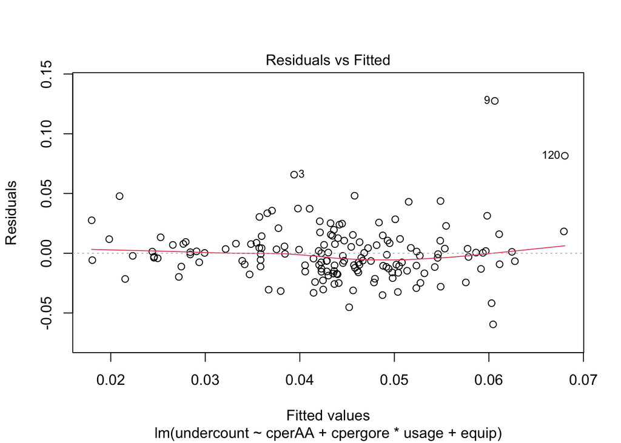

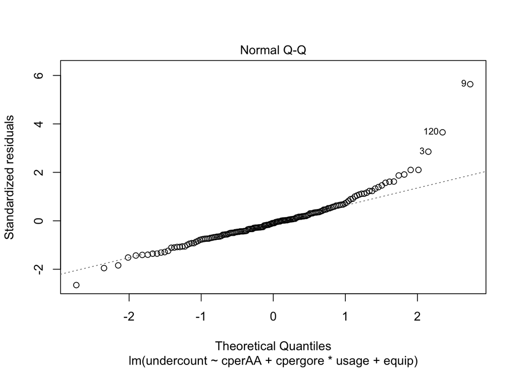

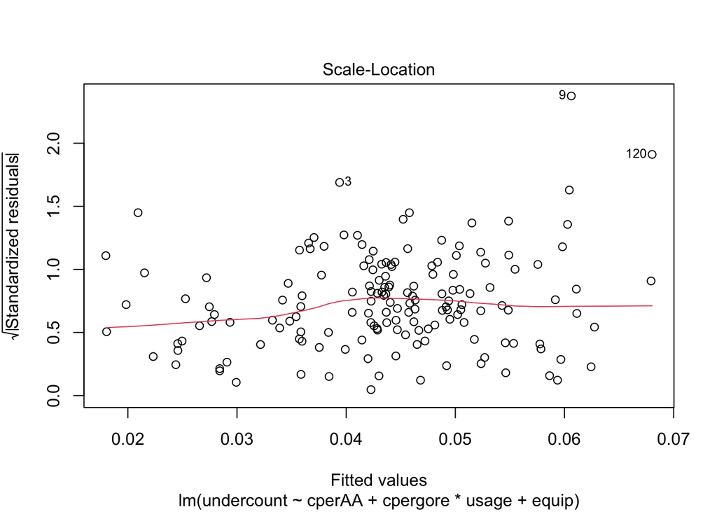

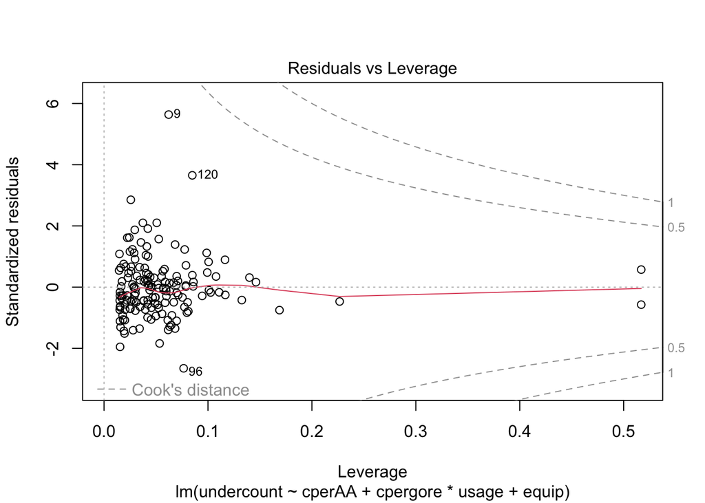

```r
plot(lmodi)
```

- The **residual-fitted value plot** is useful for checking the linearity and constant variance assumptions.
- The **scale-location plot** plots $\sqrt{|\widehat{\epsilon}_i|}$ vs fitted values and serves similar purpose as the residual-fitted value plot.
- The **QQ plot** checks for the normality assumption. It plots residuals vs the theoretical quantiles from a standard normal distribution $\Phi^{-1}\left( \frac{i}{n+1} \right)$, $i=1,\ldots,n$.
- **Residual-leverage plot**. The fitted values are
  $$\widehat{\mathbf{y}} = \mathbf{X} \widehat{\boldsymbol{\beta}} =
  \mathbf{X} (\mathbf{X}^T \mathbf{X})^{-1} \mathbf{X}^T \mathbf{y} =
  \mathbf{H} \mathbf{y}.$$
  The diagonal entries of the **hat matrix**, $h_i = H_{ii}$, are called **leverages**. For example,
  $$\text{Var}(\widehat{\boldsymbol{\epsilon}}) = \text{Var}(\mathbf{Y} -
  \mathbf{X} \widehat{\boldsymbol{\beta}}) = \text{Var} [(\mathbf{I} -
  \mathbf{H}) \mathbf{Y}] = (\mathbf{I} - \mathbf{H})
  \text{Var}(\mathbf{Y}) (\mathbf{I} - \mathbf{H}) = \sigma^2 (\mathbf{I}
  - \mathbf{H}).$$
  If $h_i$ is large, then $\text{var}(\widehat{\epsilon_i}) = \sigma^2 (1 - h_i)$ is small. The fit is “forced” to be close to $y_i$. Points on the boundary of the predictor space have the most leverage.
- The **Cook distance** is a popular influence diagnostic
  $$D_i = \frac{(\widehat{y}_i - \widehat{y}_{(i)})^T(\widehat{y}_i -
  \widehat{y}_{(i)})}{p \widehat{\sigma}^2} = \frac{1}{p} r_i^2
  \frac{h_i}{1 - h_i},$$
  where $r_i$ are the standardized residuals and $\widehat{y}_{(i)}$ are the predicted values if the $i$-th observation is dropped from data. A large residual combined with a large leverage results in a larger Cook statistic. In this sense it is an **influential point**.

  Let’s display counties with Cook distance $>0.1$. These are those two counties with unusual large `undercount`.

```r
gavote %>%
  mutate(cook = cooks.distance(lmodi)) %>%
  filter(cook >= 0.1) %>%
  print(width = Inf)
```

```
## # A tibble: 2 × 17
##   county   equip econ  perAA usage atlanta     gore  bush other votes ballots
##   <chr>    <fct> <fct> <dbl> <fct> <fct>      <int> <int> <int> <int>   <int>
## 1 BEN.HILL OS-PC poor  0.282 rural notAtlanta  2234  2381    46  4661    5741
## 2 RANDOLPH OS-PC poor  0.527 rural notAtlanta  1381  1174    14  2569    3021
##   undercount pergore perbush cpergore cperAA  cook
##        <dbl>   <dbl>   <dbl>    <dbl>  <dbl> <dbl>
## 1      0.188   0.479   0.511   0.0710 0.0390 0.234
## 2      0.150   0.538   0.457   0.129  0.284  0.138
```

- Another useful plot to inspect potential outliers in positive values is the **half-normal plot**. Here we plot the sorted leverages $h_i$ against the standard normal quantiles $\Phi^{-1} \left(\frac{n+i}{2n + 1}\right)$. We do not expect a necessary straight line, just look for outliers, which is far away from the rest of the data.

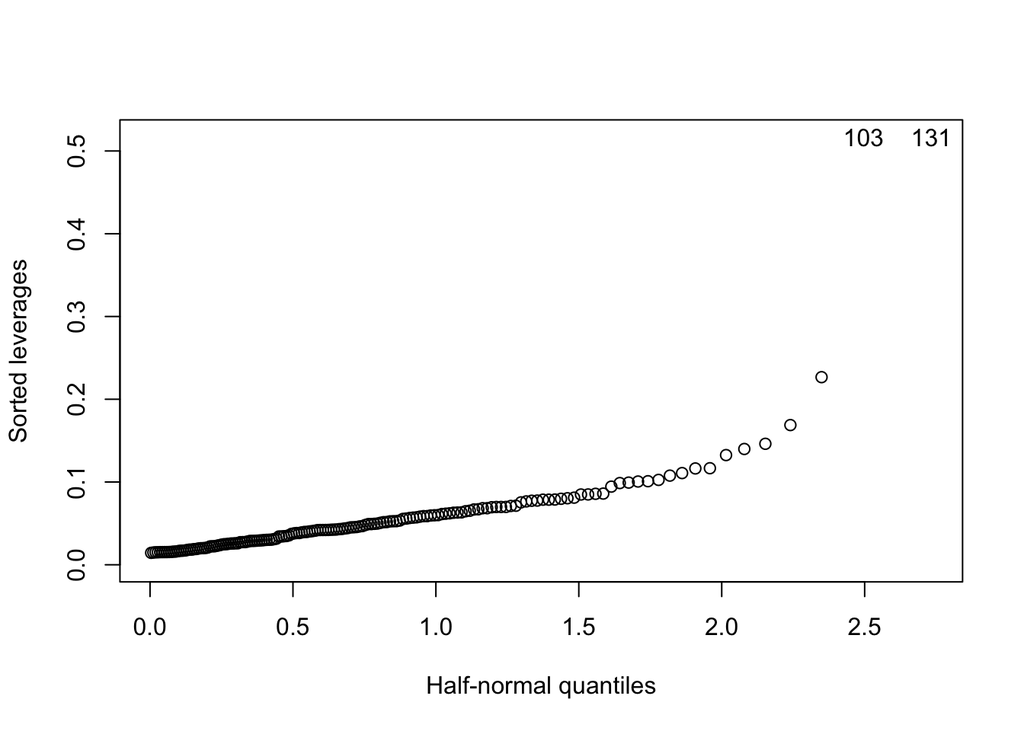

```r
# this function is available from faraway package
halfnorm(hatvalues(lmodi), ylab = "Sorted leverages")
```

These two counties have unusually large leverages. They are actually the only counties that use paper ballot.

```r
gavote %>%
  # mutate(hi = hatvalues(lmodi)) %>%
  # filter(hi > 0.4) %>%
  slice(c(103, 131)) %>%
  print(width = Inf)
```

```
## # A tibble: 2 × 16
##   county     equip econ  perAA usage atlanta     gore  bush other votes ballots
##   <chr>      <fct> <fct> <dbl> <fct> <fct>      <int> <int> <int> <int>   <int>
## 1 MONTGOMERY PAPER poor  0.243 rural notAtlanta  1013  1465    31  2509    2573
## 2 TALIAFERRO PAPER poor  0.596 rural notAtlanta   556   271     5   832     881
##   undercount pergore perbush cpergore    cperAA
##        <dbl>   <dbl>   <dbl>    <dbl>     <dbl>
## 1     0.0249   0.404   0.584 -0.00458 0.0000189
## 2     0.0556   0.668   0.326  0.260   0.353
```

## Robust regression

- In presence of outliers, if these outliers represent data entry errors, then we can simply remove these observations and proceed with linear regression.
- If these outliers are real observations, then we can use robust linear regression.

```r
library(MASS)
rlmodi <- rlm(undercount ~ cperAA + cpergore * usage + equip, gavote)
summary(rlmodi)
```

```
##
## Call: rlm(formula = undercount ~ cperAA + cpergore * usage + equip,
##     data = gavote)
## Residuals:
##        Min         1Q     Median         3Q        Max
## -6.026e-02 -1.165e-02 -6.587e-06  1.100e-02  1.379e-01
##
## Coefficients:
##                     Value   Std. Error t value
## (Intercept)          0.0414  0.0023    17.8662
## cperAA               0.0327  0.0254     1.2897
## cpergore            -0.0082  0.0418    -0.1972
## usageurban          -0.0167  0.0038    -4.4063
## equipOS-CC           0.0069  0.0038     1.8019
## equipOS-PC           0.0081  0.0048     1.6949
## equipPAPER          -0.0059  0.0138    -0.4269
## equipPUNCH           0.0170  0.0055     3.0720
## cpergore:usageurban  0.0073  0.0316     0.2298
##
## Residual standard error: 0.01722 on 150 degrees of freedom
```

Notably the regression coefficient for `equipOS-PC` changed from 0.0156 to 0.0081. It downweights the influence of two observations with `equi` being `OS-PC`.

p-values are not reported because inference for robust model is much harder than regular linear regression.

## Transformation

```r
plmodi <- lm(undercount ~ cperAA + poly(cpergore, 4) + usage + equip, gavote)
# summary(plmodi)
plmodi %>%
  tbl_regression() %>%
  bold_labels() %>%
  bold_p(t = 0.05)
```

| **Characteristic** | **Beta** | **95% CI**<sup>1</sup> | **p-value** |
| --- | --- | --- | --- |
| cperAA | 0.02 | -0.04, 0.08 | 0.5 |
| cpergore |  |  |  |
| cpergore | 0.02 | -0.10, 0.14 | 0.8 |
| cpergore² | 0.00 | -0.05, 0.05 | >0.9 |
| cpergore³ | -0.03 | -0.08, 0.01 | 0.2 |
| cpergore⁴ | 0.01 | -0.04, 0.05 | 0.8 |
| usage |  |  |  |
| rural | — | — |  |
| urban | -0.02 | -0.03, -0.01 | <0.001 |
| equip |  |  |  |
| LEVER | — | — |  |
| OS-CC | 0.01 | 0.00, 0.02 | 0.15 |
| OS-PC | 0.02 | 0.00, 0.03 | 0.010 |
| PAPER | -0.01 | -0.04, 0.03 | 0.7 |
| PUNCH | 0.01 | 0.00, 0.03 | 0.074 |

<sup>1</sup> CI = Confidence Interval

```
`termplot` graphically summarizes the effect of each predictor. `terms` argument of `termplot` function specifies which term to plot. Pratial residuals are predictor values plus residual values.
```

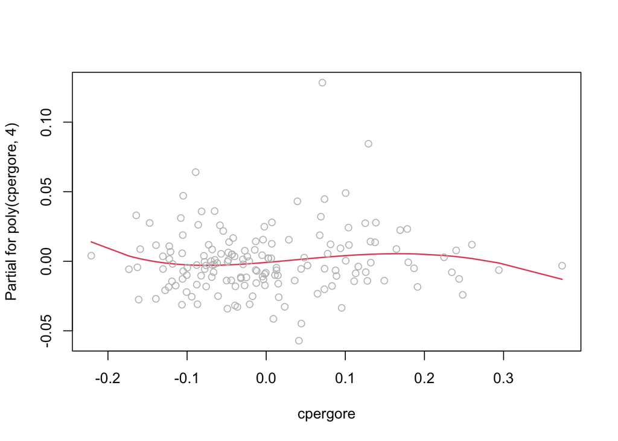

[output not shown]

```r
termplot(plmodi, partial.resid = TRUE, terms = 2)
```

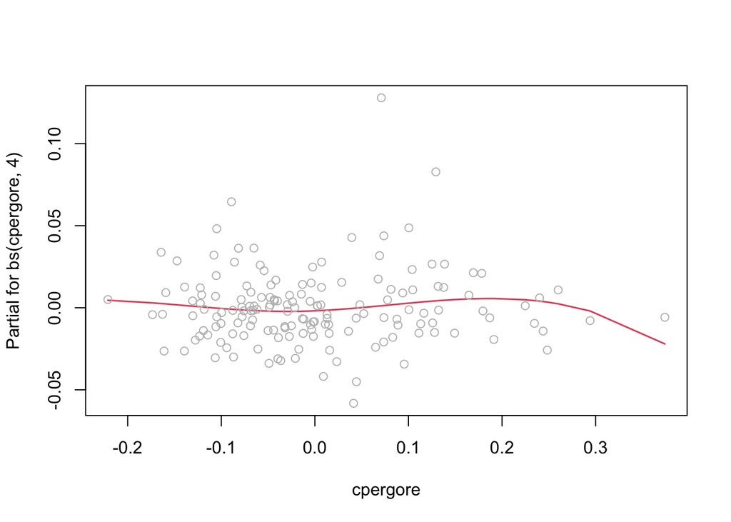

```r
library(splines)
blmodi <- lm(undercount ~ cperAA + bs(cpergore, 4) + usage + equip, gavote)
termplot(blmodi, partial.resid = TRUE, terms = 2)
```

## Variable selection

Variable selection concerns the problem of selecting the best set of variables to put in a model. There are several approaches and it is still an active research area.

- **Exhaustive search**, also called **all-subset regression**, enumerates all $2^p$ submodels and selects the best one according to a criterion such as the adjusted $R^2$. The `regsubsets` function in the `leaps` package implements this search. The implementation only applies to quantitative predictors.
- When there are many predictors, all-subset regression quickly becomes computationally infeasible. **Stepwise regression** does heuristic search. A popular criterion is the **Akaike Information Criterion** (AIC)
  $$\text{AIC} = - 2 \cdot \text{maximum log-likelihood} + 2p,$$
  where $p$ is the number of parameters. We start with a big model that includes all two-way interactions between qualitative predictors and all two-way interactions between qualitative and quantitative predictors

```r
biglm <- lm(undercount ~ (equip + econ + usage + atlanta)^2 + (equip + econ +
  usage + atlanta) * (perAA + pergore), gavote)
```

The `step` command sequentially eliminates terms to minimize the AIC:

```r
(smallm <- step(biglm, trace = TRUE))
```

```
## Start:  AIC=-1203.9
## undercount ~ (equip + econ + usage + atlanta)^2 + (equip + econ +
##     usage + atlanta) * (perAA + pergore)
##
##                   Df Sum of Sq      RSS     AIC
## - econ:pergore     2 0.0000231 0.048896 -1207.8
## - equip:atlanta    2 0.0000367 0.048909 -1207.8
## - econ:perAA       2 0.0000993 0.048972 -1207.6
## - econ:usage       2 0.0003513 0.049224 -1206.8
## - equip:usage      3 0.0011993 0.050072 -1206.0
## - equip:econ       6 0.0031630 0.052035 -1205.9
## - usage:perAA      1 0.0000015 0.048874 -1205.9
## - atlanta:pergore  1 0.0000055 0.048878 -1205.9
## - atlanta:perAA    1 0.0000195 0.048892 -1205.8
## - usage:pergore    1 0.0001094 0.048982 -1205.5
## - usage:atlanta    1 0.0001774 0.049050 -1205.3
## - econ:atlanta     1 0.0004666 0.049339 -1204.4
## <none>                         0.048872 -1203.9
## - equip:pergore    3 0.0020637 0.050936 -1203.3
## - equip:perAA      3 0.0022945 0.051167 -1202.6
##
## Step:  AIC=-1207.83
## undercount ~ equip + econ + usage + atlanta + perAA + pergore +
##     equip:econ + equip:usage + equip:atlanta + econ:usage + econ:atlanta +
##     usage:atlanta + equip:perAA + equip:pergore + econ:perAA +
##     usage:perAA + usage:pergore + atlanta:perAA + atlanta:pergore
##
##                   Df Sum of Sq      RSS     AIC
## - equip:atlanta    2 0.0000473 0.048943 -1211.7
## - econ:perAA       2 0.0002786 0.049174 -1210.9
## - econ:usage       2 0.0003498 0.049245 -1210.7
## - equip:usage      3 0.0011820 0.050078 -1210.0
## - atlanta:pergore  1 0.0000016 0.048897 -1209.8
## - usage:perAA      1 0.0000108 0.048906 -1209.8
## - atlanta:perAA    1 0.0000342 0.048930 -1209.7
## - equip:econ       6 0.0032132 0.052109 -1209.7
## - usage:pergore    1 0.0000891 0.048985 -1209.5
## - usage:atlanta    1 0.0001901 0.049086 -1209.2
## - econ:atlanta     1 0.0005762 0.049472 -1208.0
## <none>                         0.048896 -1207.8
```

[output cut: 168 more lines]

```
## - pergore      1 0.0005162 0.053627 -1231.1
## <none>                     0.053111 -1230.7
## - usage:perAA  1 0.0012458 0.054357 -1229.0
## - equip:econ   6 0.0072977 0.060409 -1222.2
## - equip:perAA  4 0.0072498 0.060361 -1218.3
##
## Step:  AIC=-1231.14
## undercount ~ equip + econ + usage + perAA + equip:econ + equip:perAA +
##     usage:perAA
##
##               Df Sum of Sq      RSS     AIC
## <none>                     0.053627 -1231.1
## - usage:perAA  1 0.0010214 0.054649 -1230.1
## - equip:econ   6 0.0075232 0.061150 -1222.3
## - equip:perAA  4 0.0068439 0.060471 -1220.0
```

```
##
## Call:
## lm(formula = undercount ~ equip + econ + usage + perAA + equip:econ +
##     equip:perAA + usage:perAA, data = gavote)
##
## Coefficients:
##         (Intercept)           equipOS-CC           equipOS-PC
##           0.0435310           -0.0128784            0.0034922
##          equipPAPER           equipPUNCH             econpoor
##          -0.0578329           -0.0142618            0.0180113
##            econrich           usageurban                perAA
##          -0.0157358           -0.0006736           -0.0389879
## equipOS-CC:econpoor  equipOS-PC:econpoor  equipPAPER:econpoor
##          -0.0114503            0.0424178                   NA
## equipPUNCH:econpoor  equipOS-CC:econrich  equipOS-PC:econrich
##          -0.0160832            0.0047127           -0.0111987
## equipPAPER:econrich  equipPUNCH:econrich     equipOS-CC:perAA
##                  NA            0.0168340            0.1181524
##    equipOS-PC:perAA     equipPAPER:perAA     equipPUNCH:perAA
##           0.0321434            0.1260840            0.1243346
##    usageurban:perAA
##          -0.0472147
```

- We could further refine the model by F-tests.

```r
drop1(smallm, test = "F")
```

```
## Single term deletions
##
## Model:
## undercount ~ equip + econ + usage + perAA + equip:econ + equip:perAA +
##     usage:perAA
##             Df Sum of Sq      RSS     AIC F value   Pr(>F)
## <none>                   0.053627 -1231.1
## equip:econ   6 0.0075232 0.061150 -1222.3  3.2500 0.005084 **
## equip:perAA  4 0.0068439 0.060471 -1220.0  4.4348 0.002101 **
## usage:perAA  1 0.0010214 0.054649 -1230.1  2.6474 0.105984
## ---
## Signif. codes:  0 '***' 0.001 '**' 0.01 '*' 0.05 '.' 0.1 ' ' 1
```

It shows `usage:perAA` term can be dropped.

## Final model

- So our final model is

```r
finalm <- lm(undercount ~ equip + econ + perAA + equip:econ + equip:perAA, gavote)
summary(finalm)
```

```
##
## Call:
## lm(formula = undercount ~ equip + econ + perAA + equip:econ +
##     equip:perAA, data = gavote)
##
## Residuals:
##       Min        1Q    Median        3Q       Max
## -0.057011 -0.010632 -0.000069  0.009198  0.082545
##
## Coefficients: (2 not defined because of singularities)
##                      Estimate Std. Error t value Pr(>|t|)
## (Intercept)          0.041871   0.005028   8.328  6.5e-14 ***
## equipOS-CC          -0.011327   0.007373  -1.536 0.126700
## equipOS-PC           0.008575   0.011178   0.767 0.444288
## equipPAPER          -0.058427   0.037014  -1.579 0.116687
## equipPUNCH          -0.015751   0.018745  -0.840 0.402175
## econpoor             0.020266   0.005529   3.665 0.000349 ***
## econrich            -0.016966   0.012392  -1.369 0.173128
## perAA               -0.042040   0.016594  -2.534 0.012385 *
## equipOS-CC:econpoor -0.010964   0.009885  -1.109 0.269224
## equipOS-PC:econpoor  0.048385   0.013795   3.507 0.000608 ***
## equipPAPER:econpoor        NA         NA      NA       NA
## equipPUNCH:econpoor -0.003560   0.012427  -0.286 0.774921
## equipOS-CC:econrich  0.002278   0.015378   0.148 0.882465
## equipOS-PC:econrich -0.013318   0.017054  -0.781 0.436149
## equipPAPER:econrich        NA         NA      NA       NA
## equipPUNCH:econrich  0.020031   0.021997   0.911 0.364045
## equipOS-CC:perAA     0.107249   0.032855   3.264 0.001377 **
## equipOS-PC:perAA    -0.005906   0.043414  -0.136 0.891981
## equipPAPER:perAA     0.129136   0.081806   1.579 0.116676
## equipPUNCH:perAA     0.086849   0.046500   1.868 0.063875 .
## ---
## Signif. codes:  0 '***' 0.001 '**' 0.01 '*' 0.05 '.' 0.1 ' ' 1
##
## Residual standard error: 0.02 on 141 degrees of freedom
## Multiple R-squared:  0.4276, Adjusted R-squared:  0.3585
## F-statistic: 6.195 on 17 and 141 DF,  p-value: 1.318e-10
```

The coefficient for `equipPAPER:econrich` is not estimated because there are no counties that are rich and use paper ballot. The corresponding column in $\mathbf{X}$ matrix is all zeros.

```r
gavote %>%
  filter(equip == "PAPER" & econ == "rich") %>%
  count()
```

```
## # A tibble: 1 × 1
##       n
##   <int>
## 1     0
```

The coefficient for `equipPAPER:econpoor` is not estimated because there are only two counties that use paper ballot and both of them are poor. So the corresponding colmuns for `equipPAPER` and `equipPAPER:econpoor` are identical. In other words these two predictors are not identifiable. Therefore only `equipPAPER` is estimated but not `equipPAPER:econpoor`.

```r
gavote %>%
  filter(equip == "PAPER")
```

```
## # A tibble: 2 × 16
##   county equip econ  perAA usage atlanta  gore  bush other votes ballots under…¹
##   <chr>  <fct> <fct> <dbl> <fct> <fct>   <int> <int> <int> <int>   <int>   <dbl>
## 1 MONTG… PAPER poor  0.243 rural notAtl…  1013  1465    31  2509    2573  0.0249
## 2 TALIA… PAPER poor  0.596 rural notAtl…   556   271     5   832     881  0.0556
## # … with 4 more variables: pergore <dbl>, perbush <dbl>, cpergore <dbl>,
## #   cperAA <dbl>, and abbreviated variable name ¹undercount
```

- Let’s attempt predictions at all combination of levels of `econ` and `equip` at median `perAA`

```r
(pdf <- tibble(econ  = rep(levels(gavote$econ), 5),
               equip = rep(levels(gavote$equip), rep(3, 5)),
               perAA = 0.233))
```

```
## # A tibble: 15 × 3
##    econ   equip perAA
##    <chr>  <chr> <dbl>
##  1 middle LEVER 0.233
##  2 poor   LEVER 0.233
##  3 rich   LEVER 0.233
##  4 middle OS-CC 0.233
##  5 poor   OS-CC 0.233
##  6 rich   OS-CC 0.233
##  7 middle OS-PC 0.233
##  8 poor   OS-PC 0.233
##  9 rich   OS-PC 0.233
## 10 middle PAPER 0.233
## 11 poor   PAPER 0.233
## 12 rich   PAPER 0.233
## 13 middle PUNCH 0.233
## 14 poor   PUNCH 0.233
## 15 rich   PUNCH 0.233
```

```r
pp <- predict(finalm, new = pdf)
xtabs(round(pp, 3) ~ econ + equip, pdf)
```

```
##         equip
## econ      LEVER  OS-CC  OS-PC  PAPER  PUNCH
##   middle  0.032  0.046  0.039  0.004  0.037
##   poor    0.052  0.055  0.108  0.024  0.053
##   rich    0.015  0.031  0.009 -0.013  0.040
```

- Predictions at some combinations of `propAA` and `equip`

```r
pdf <- tibble(econ  = rep("middle", 15),
              equip = rep(levels(gavote$equip), rep(3, 5)),
              perAA = rep(c(.11, 0.23, 0.35), 5))
pp <- predict(finalm, new = pdf)
propAA <- gl(3, 1, 15, labels = c("low", "medium", "high"))
xtabs(round(pp, 3) ~ propAA + equip, pdf)
```

```
##         equip
## propAA    LEVER  OS-CC  OS-PC  PAPER  PUNCH
##   low     0.037  0.038  0.045 -0.007  0.031
##   medium  0.032  0.046  0.039  0.003  0.036
##   high    0.027  0.053  0.034  0.014  0.042
```

## Conclusion

**BACKGROUND**: The controversy surrounding the 2000 US presidential election highlighted the potential impact of voting equipment on voting errors. However, most existing studies have focused on examining voting equipment across states, rather than within individual states, potentially leading to aggregation bias. Furthermore, social-economic status and race have not been adequately considered in previous research.

**OBJECTIVE**: This study aimed to identify the factors influencing voting errors in the state of Georgia, taking into account social-economic status and race.

**METHOD**: Data from the Georgia Secretary of State’s Election Administration Web site for the 2000 general election were used to calculate the percentage of unrecorded votes over the total ballots issued in each county. A linear regression analysis was performed to explore the factors contributing to undercounts.